# Predict The Next Pitch

## Define the problem

##### What is the problem you're trying to solve, why is it important to solve it?

Baseball has become a very analytical sport and now it seems as if everything can be analyzed with data. In this new world, teams have started to implement numerous analytical techniques including defensive shifts, individual statistical importance, batter tendencies based on pitch locations, etc. This data based strategy had become popular from Billy Bean and his Sabermetrics. Here, I will try to apply another statistical approach on the basis on machine-learning by trying to predict the next pitch a pitcher will throw by incorporating information that is available to a batter such as the count, the current game state, pitcher’s tendency to throw a particular type of pitch, etc. This becomes a multi-classification problem by predicting the next pitch type.

##### How does it affect people? How does it affect you?

Competitive sport teams will do anything to win, deflating footballs or scuffling baseballs for instance. This new technique of pitch prediction can help teams gain a competitive advantage against their competitor. This strategy can help the offensive team by telling them the next pitch thrown by the pitcher for that current situation. This technique can also inform the current team’s pitcher of how predictable he can be and that he needs to mix up his pitches better. Even though some players will always be stubborn and refuse this information, since they will always believe human intuition is the only way the play baseball, this technique can greatly increase the pitch guess expectations. This problem affects me and is close to my heart as a former college baseball player, as it would have been useful to know some of this information when I played.

## Describe a solution

##### How accurate do your results need to be? How quickly does your algorithm need to produce an answer?

To make this an suitable prediction problem, the prediction accuracy needs to above the random guess line (25% for a pitcher with 4 pitches distributed evenly) and probably closer to 10-15% accuracy above the random guess line to have any real effect on teams. The suitable metric in this situation would be classification accuracy with the only the correct pitch type being acceptable (number correct / total pitches). With a multi classification problem we could not use any binary metrics like ROC curves and as this is not a binary (yes / no) problem. Unlike a binary problem, the accuracy in this instance will not be as high, since there are many different types of pitches that could be thrown. We could predict fastball / off speed to make it a binary problem and would expect the classification accuracy to be higher, however it is more intuitive to use multiclass prediction.

The runtime of the algorithm would not matter a great and not need to be super fast, as a team could run the algorithm well before they needed it. However, the prediction process run time becomes much more important in one case. If the algorithm is used during a game, it would need to be run on a pitch by pitch basis and therefore need to produce an answer quickly. The other tactic to use the algorithm is that it could be used before the game to gain some insight on pitcher tendencies and would not need to be as quick. The run time of the algorithm also will depend on the current dataset being read into the pandas dataframe. Therefore a pitcher with more tenure in the league, meaning that they will have more games played, will have thrown more pitches, and thus more rows in the data frame.

```python
# import libraries
import numpy as np
import pandas as pd
import io
from __future__ import division
# plotting
import matplotlib.pyplot as plt
import seaborn as sns
plt.style.use('ggplot')
% matplotlib inline
# website parsing
from bs4 import BeautifulSoup
import urllib2
# ignore warnings
import warnings
warnings.filterwarnings('ignore')
```

Set up dictionary to map name to player_id for webscraping

```python
# all players lookup table
# only added a select few
players = {'Dallas Keuchel': 572971,
          'Jake Arrieta': 453562,
          'Madison Bumgarner': 518516,
          'Clayton Kershaw': 477132,
          'Sonny Gray': 543243,
          'Justin Verlander': 434378,
          'Jacob deGrom': 594798}
```

Download the desired player information and save to csv file, if not already saved

```python
def player_data(name):
    '''Receives Player Full Name, downloads pitch individual game data from www.brooksbaseball.net
        and saves it to created csv, if is data already uploaded it reads from file'''
    player_id = players[name]

    try:
        dat = pd.read_csv('players/' + name + '.csv')

    except:
        url = 'http://www.brooksbaseball.net/tabs.php?player={}&p_hand=-1&ppos=-1&cn=200&compType=none&gFilt=&time=month&minmax=ci&var=gl&s_type=2&startDate=03/30/2007&endDate=11/24/2015&balls=-1&strikes=-1&b_hand=-1'.format(player_id)

        source = urllib2.urlopen(url).read()
        soup = BeautifulSoup(source)
        link_list = [l.get('href') for l in soup.findAll('a')]

        desired_links = []

        for l in link_list:
            if l is not None and l[:50] == 'http://www.brooksbaseball.net/pfxVB/pfx.php?s_type':
                desired_links.append(l)

        data_link = []

        for url in desired_links:
            source = urllib2.urlopen(url).read()
            soup = BeautifulSoup(source)
            link_list = [l.get('href') for l in soup.findAll('a')]

            for l in link_list:
                if l is not None and l[:15] == 'tabdel_expanded':
                    data_link.append(l)

        all_data_links = []
        for i in data_link:
            all_data_links.append('http://www.brooksbaseball.net/pfxVB/' + i)

        dat = pd.DataFrame()
        for table in all_data_links:
            new_dat = pd.read_html(table, header = 0)[0]
            new_dat['pitch_count'] = new_dat.index + 1
            dat = dat.append(new_dat)

        dat.to_csv('players/' + name + '.csv', index = False)

    return dat
```

Read in Player Data

```python
dat = player_data('Justin Verlander')
```

## Feature Creation and Transformation

Delete Intential Walk pitches and Pitch Outs as these do not need to be predicted

```python
# delete intential walk pitches
dat = dat[dat['mlbam_pitch_name'] != 'IN']
# delete pitch out pitches
dat = dat[dat['mlbam_pitch_name'] != 'PO']
```

Add if play results in an out

```python
def add_out(row):
    outs = 0
    if row[-6:] == 'out(s)':
        outs = 1
    return outs

dat['out'] = dat['pdes'].apply(add_out)
```

Add current number of outs to the current situtation

```python
# set limit so number of outs stops at 3
limit = 3
dat['outs'] = np.cumsum(dat['out']) % limit
dat['outs'] = dat['outs'].shift(1)
dat['outs'] = dat['outs'].fillna(0)
```

Alter and bin numerical pitch location numbers to corresponding pitch location category

```python
def pitch_location(row):
    zone, batter = row
    if batter == 'R':
        if zone in [0,1,5,6,10,11,15,16,20,21]:
            return 'inside'
        elif zone in [2,7,12,17,22]:
            return 'center'
        else:
            return 'outside'
    if batter == 'L':
        if zone in [0,1,5,6,10,11,15,16,20,21]:
            return 'outside'
        elif zone in [2,7,12,17,22]:
            return 'center'
        else:
            return 'inside'

dat['pitch_location'] = dat[['zone_location', 'stand']].apply(pitch_location, axis = 1)
```

Shift columns to add previous pitches for prediction. This will help determine the next pitch as it is often based on the previous pitch

```python
dat['prev_pitch_outcome'] = dat['pdes'].shift(1)
dat['prev_pitch_speed'] = dat['start_speed'].shift(1)
dat['prev_pitch_location'] = dat['pitch_location'].shift(1)
dat['prev_pdes'] = dat['pdes'].shift(1)
dat['prev_des'] = dat['des'].shift(1)
dat['prev_out'] = dat['out'].shift(1)
```

Change the dependant, `y` to make all different types of fastballs into one, and add previous pitch to next pitch

```python
def convert_pitches(row):
    if row in ['FA', 'FC', 'FF', 'FT', 'FS', 'UN', 'SI']:
        return 'FB'
    else:
        return row

dat['current_pitch'] = dat['mlbam_pitch_name'].apply(convert_pitches)
dat['prev_pitch_type'] = dat['current_pitch'].shift(1)
```

Pitch percentage by pitch. Sorted in alphabetical order for reproducability and so it matches with sklearn's Label Encoder. Also set pitch column list to add desired columns to `X` dataframe for reproducability for each different pitcher

```python
pitch_percentage = []

for pitch in dat.current_pitch.order().unique():
    percent = len(dat.current_pitch[dat.current_pitch == pitch]) / dat.shape[0]
    pitch_percentage.append(percent)
    dat[pitch] = percent

pitch_columns = []
for column in dat.current_pitch.order().unique():
    pitch_columns.append(column)

zip(dat.current_pitch.order().unique(), pitch_percentage)
```

```
[('CH', 0.1960534898891063),
 ('CU', 0.16128506196999348),
 ('FB', 0.5460861056751468),
 ('SL', 0.09657534246575343)]
```

Bin `prev_pitch_speed` for prediction

```python
if np.max(dat.prev_pitch_speed) > 90:
    max_speed = np.max(dat.prev_pitch_speed)
else:
    max_speed = 95

bins = [70, 75, 80, 85, 90, max_speed]
dat['prev_pitch_speed_bins'] = pd.cut(dat.prev_pitch_speed, bins = bins, include_lowest = True)
```

Pick out the ballpark city where the game is being played. Some parks are smaller and so are bigger as this could influence the type of pitch

```python
dat['park'] = dat.park_sv_id.map(lambda x: x[-3:])
```

Pick out the day, month, year

```python
dat['day'] = dat.dateStamp.map(lambda x: x[-2:])
dat['month'] = dat.dateStamp.map(lambda x: x[5:7])
dat['year'] = dat.dateStamp.map(lambda x: x[:4])
```

Show Data Head

```python
dat.head()
```

|  | ab_count | ab_id | ab_total | ax | ay | az | balls | batter_id | dateStamp | des | ... | prev_pitch_type | CH | CU | FB | SL | prev_pitch_speed_bins | park | day | month | year |
| --- | --- | --- | --- | --- | --- | --- | --- | --- | --- | --- | --- | --- | --- | --- | --- | --- | --- | --- | --- | --- | --- |
| 0 | 1 | 6 | 4 | -22.113000 | 35.212001 | -21.071001 | 0 | 117863 | 2007-06-06 | Fly Out | ... | NaN | 0.196053 | 0.161285 | 0.546086 | 0.096575 | NaN | tex | 06 | 06 | 2007 |
| 1 | 2 | 6 | 4 | -16.203000 | 36.359000 | -16.427000 | 0 | 117863 | 2007-06-06 | Fly Out | ... | FB | 0.196053 | 0.161285 | 0.546086 | 0.096575 | (90, 103.33] | tex | 06 | 06 | 2007 |
| 2 | 3 | 6 | 4 | -10.175000 | 24.261001 | -25.385000 | 1 | 117863 | 2007-06-06 | Fly Out | ... | FB | 0.196053 | 0.161285 | 0.546086 | 0.096575 | (90, 103.33] | tex | 06 | 06 | 2007 |
| 3 | 4 | 6 | 4 | -18.613999 | 32.491000 | -18.166000 | 2 | 117863 | 2007-06-06 | Fly Out | ... | CH | 0.196053 | 0.161285 | 0.546086 | 0.096575 | (80, 85] | tex | 06 | 06 | 2007 |
| 4 | 1 | 7 | 5 | 5.524000 | 24.919000 | -40.964000 | 0 | 276545 | 2007-06-06 | Strikeout | ... | FB | 0.196053 | 0.161285 | 0.546086 | 0.096575 | (90, 103.33] | tex | 06 | 06 | 2007 |

5 rows × 72 columns

## Analyze the problem

### Exploratory Data Analysis

#### What is the size of your dataset?

```python
print 'The current pitchers dataset has {} rows and {} columns'.format(*dat.shape)
```

```
The current pitchers dataset has 30660 rows and 72 columns
```

#### How many features are present?

```python
# number of featues, subtract 2, one for the original predictor
# and one for my newly created predictor that will replace the original
print 'There are {} number of features present'.format(len(dat.columns) - 2)
```

```
There are 70 number of features present
```

##### Which features seem most promising?

The features that seem to be the most promising in this dataset are `strikes`, `balls`, `inning`, `prev_pitch_type`, and `prev_pdes`. With some substantive expertise in this area, the situation of the at-bat, the stance of the player, and history of the batter is probably the most important. With only a subset of the desired features, strikes, balls and previous pitch type seem be the most important here.

#### Are there any categorical variables that may need to be converted?

With basically the entire dataset being categorical variables, I will need to convert many features. Therefore, mostly all the created and transformed predictors will need to be converted to dummy variables and/or bined, with exception to a couple which we already suitable and close enough to being normalized (-1 / 1) and don't needed to be scaled. These variables including `stand`, `prev_pitch_type`, `prev_pitch_outcome`, `prev_pitch_location`, `prev_pdes`, `prev_des`, `prev_pitch_speed_bins`, and `inning`. The issue here is that this will create a ton of new columns in the dataframe and make the runtime of the classifier much more complex and slower, so I will probably subset these columns before I pass the `X` predictors into the algorithm.

#### Graphical Representations

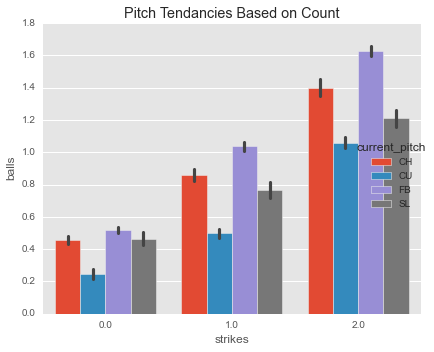

```python
sns.factorplot(x = 'strikes', y = 'balls', data = dat, hue = 'current_pitch')
plt.title('Pitch Tendancies Based on Count')
plt.tight_layout()
```

What the Pitcher throws based on inning and how the regression lines for pitches

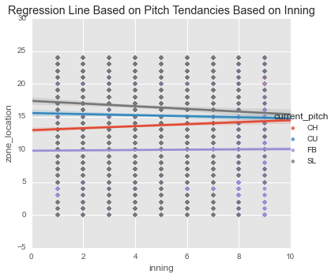

```python
sns.lmplot(x = 'inning', y = 'zone_location', data = dat, hue = 'current_pitch')
plt.title('Regression Line Based on Pitch Tendancies Based on Inning')
plt.tight_layout()
```

Previous Pitch Outcome By Inning

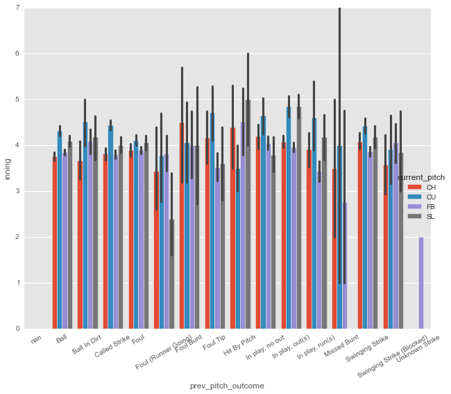

```python
g = sns.factorplot('prev_pitch_outcome', 'inning', hue = 'current_pitch', data = dat, size = 8)
g.set_xticklabels(rotation=30)
plt.tight_layout()
```

Separate pitches by spin

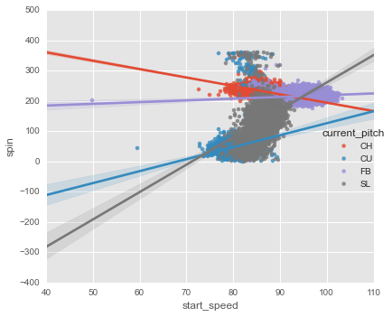

```python
sns.lmplot('start_speed', 'spin', hue = 'current_pitch', data = dat)
plt.tight_layout()
```

Pitch tendency and pitch location based on the strike zone

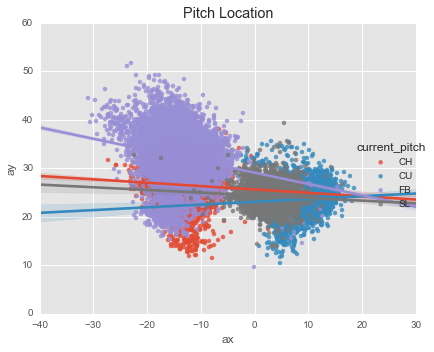

```python
sns.lmplot(x = 'ax', y = 'ay', data = dat, hue = 'current_pitch')
plt.title('Pitch Location')
plt.tight_layout()
```

### Basic Statistics

Correlation plot between numerical features, although not extremely readable and may of these features will not be used as alot are not suitable for analysis, but it can help determine some highly correlated feature in this datset

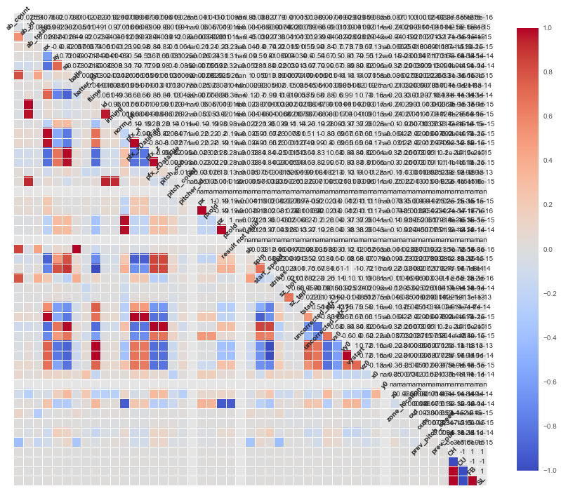

```python
plt.figure(figsize=(12,12))

sns.corrplot(dat)
plt.tight_layout()
```

Function to convert categorical variables to dummy variables and insert them into a new data frame. I will later combine this newly created `dummy_dat` dataframe with the original numerical features from `dat` for predictions

```python
def preprocess_features(X):
    outX = pd.DataFrame(index=X.index)

    for col, col_data in X.iteritems():
        teams = pd.get_dummies(col_data, prefix = col)
        outX = outX.join(teams)
    return outX

dummy_dat = preprocess_features(dat[['stand', 'prev_pitch_type', 'prev_pitch_outcome', 'prev_pitch_location',
                                     'prev_pdes', 'prev_des', 'prev_pitch_speed_bins', 'inning', 'ab_count',
                                     'park', 'month', 'year']])
```

### Machine Learning Algorithms

#### Which machine learning algorithms would you expect to perform well?

1) Support Vector Machine

- Using a soft-margin as their might be certain data points that might need to overlap the margin and they could be ignored easily and SVM can easily extend to a nonlinear boundary with the use of kernels. I will need to use either OneVsRest or OneVsOne to make an SVM work with multi-class.

2) Naive Bayes Classification

- I can incorporate class priors to use a bayesian approach to denote my prior beliefs in each pitch being thrown. Therefore, I can try and influence the data with the mean of each pitch being thrown. For multi-class classification, I can use MultinomialNB, however if I do introduce negative values into the classification, Naive Bayes will have trouble and cannot be used.

3) Decision Tree

- Can work with a tree like structure to simulate a the decision process. I like this technique in this type of problem as it sort of replicates the human brain and stimulates questions being contemplated before each pitch. It becomes like a person thinking process and will my background in this area this is how a pitcher thinks although it might not be as apparent, but subconsciously a pitcher will go through many of these steps.

4) Ensemble Methods - Random Forest and Gradient Boosted Machines

- Incorporate the decision tree structure with the improved accuracy. GBM can also learn based on the previous mistakes and classify more appropriately on what it gets incorrect.

##### How easy is it to convert the available data into a suitable form?

With being data scraped from a website, this data took some wrangling to get it into a desired format to even create a problem to be solved. I had to alter and create many different columns and shift rows around to be able to perform the suitable task. This was definitely not a simple read in and chung type of problem, as I had to perform multiple steps to just get it into the correct format. But as they say 80% of the time doing Machine Learning is data acquisition and data wrangling, and no different here. Another thing I had to account for is that I also had to make this compatible with every different pitcher read into the data frame. I had to make sure that the columns and rows will line up with different datasets, since different pitchers will throw a different number of pitches. This format will build a separate algorithm for each pitcher's data. Therefore, this way it will scale well.

Set up data for sklearn and predcition, X is independant features and y is dependant. Sklearn's LabelEncoder for the `y` dependant spits out the names in alphabetical order so we had to match that order above

###### Feature Vector

The Feature Vector consists of Batter Stance, Previous Pitch Type, Previous Pitch Outcome, Previous Pitch Location, Previous Description, Previous Pitch Speed, if there was a Previous Out, Current Inning, At Bat Pitch Count, Ballpark, Current Month, Current Year, and the Number of strikes, balls, and outs.

```python
X_df = dat[['strikes', 'balls', 'outs', 'prev_out', 'pxold', 'pzold'] + pitch_columns]
X_df = X_df.join(dummy_dat)
X_df[np.isnan(X_df)] = 0
X = dat[['strikes', 'balls', 'outs', 'prev_out','pxold', 'pzold'] + pitch_columns]
X = X.join(dummy_dat)
X = X.values
X[np.isnan(X)] = 0
y = dat['current_pitch'].values

X.shape
```

```
(30660, 152)
```

```python
from sklearn.preprocessing import LabelEncoder

le = LabelEncoder()
le.fit_transform(y)
le.classes_
```

```
array(['CH', 'CU', 'FB', 'SL'], dtype=object)
```

## Implement a solution

##### What pre-processing operations do you have to carry out on the features? (e.g. scaling, normalization, selection, transformation)

There are a couple of different preprocessing steps needed for this dataset. Scaling and normalization are not really needed in this analysis as almost all of the data has been transformed into dummy variables / bins and the ones that are not are already low enough values and suitable for the algorithms. The two steps that were really needed are transformation and selection of features. Transformation becomes present as I had to create multiple new columns to be able to work with this data and even have a question to answer. Also feature selection is going to be necessary as there will probably be a lot of features with all of the dummy variables created and I will likely want to shorten the amount of features for a more precise solution.

##### Are there any incomplete data points or outliers that you have to work around?

In this dataset there aren't really any outliers as all of the points are reasonable for a pitcher. For example, there are not any pitches that were thrown 120 mph or any erroneous amounts. The only data points that aren't suitable for analysis were a couple type pitches, including intentional walks and pitch outs. The good news here is that I can simply just delete these points as intentional walks don’t need to be predicted and pitch out are so rare and aren't determined by previous actions, but the player on base.

### PCA

I incorporate Principal Component Analysis to get a better feel of the data. First I reduce the data into two dimensions so I can visualize them easily and produce a plot. Next I perform cluster analysis with Gaussian Mixture Model Clustering to split the data into the number of unique pitches the pitcher throws. Then, create a mesh grid for the reduced data, predict on the clustering and get the cluster centers and plot the data in two dimensions. This is more of an EDA approach rather than a unsupervised tactic.

```python
from sklearn.decomposition import PCA
from sklearn.cluster import KMeans
from sklearn.mixture import GMM

# reduce data to two dimensions
reduced_data = PCA(n_components = 2).fit_transform(X)

# initialize and fit cluster algorithm
# clusters = KMeans(n_clusters = len(le.classes_), random_state = 100).fit(reduced_data)
clusters = GMM(n_components = len(le.classes_), random_state = 100).fit(reduced_data)
```

```python
# mesh grid for plotting
x_min, x_max = reduced_data[:, 0].min() - 1, reduced_data[:, 0].max() + 1
y_min, y_max = reduced_data[:, 1].min() - 1, reduced_data[:, 1].max() + 1
hx = (x_max - x_min) / 1000.
hy = (y_max - y_min) / 1000.
xx, yy = np.meshgrid(np.arange(x_min, x_max, hx), np.arange(y_min, y_max, hy))

# Obtain labels for each point in mesh grid
Z = clusters.predict(np.c_[xx.ravel(), yy.ravel()])

# centroids = clusters.cluster_centers_
centroids = clusters.means_
```

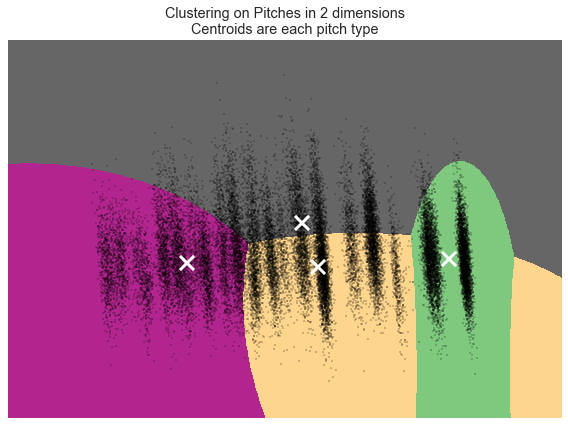

```python
plt.figure(figsize=(8,6))

Z = Z.reshape(xx.shape)

plt.imshow(Z, interpolation = 'nearest',
           extent = (xx.min(), xx.max(), yy.min(), yy.max()),
           cmap = plt.cm.Accent_r, aspect = 'auto', origin = 'lower')

plt.plot(reduced_data[:, 0], reduced_data[:, 1], 'k.', markersize=2)

plt.scatter(centroids[:, 0], centroids[:, 1], marker = 'x', s = 200,
            linewidths = 3, color = 'w', zorder = 10)

plt.title('Clustering on Pitches in 2 dimensions\n'
          'Centroids are each pitch type')
plt.xlim(x_min, x_max)
plt.ylim(y_min, y_max)
plt.xticks(())
plt.yticks(())
plt.tight_layout()
```

Now I can filter the features with Sklearn's SelectKBest. We have two different choices here with a classification problem we can either use `f_classif` or `chi2`. The `f_classif` computes the ANOVA F-value for the provided sample and the `chi2` computes chi-squared stats between each non-negative feature and class. This score can be used to select the n_features features with the highest values for the test chi-squared statistic from X. The chi-square test measures dependence between stochastic variables, so using this function “weeds out” the features that are the most likely to be independent of class and therefore irrelevant for classification. *SKLEARN* I can experiment with the correct number of features to chosen model. I originally used chi2, but when I added a couple new input vectors that included negative values I will forced to switch to `f_classif` and using the F-Value from the ANOVA test.

```python
from sklearn.feature_selection import SelectKBest
from sklearn.feature_selection import chi2
from sklearn.feature_selection import f_classif

X_new = SelectKBest(f_classif, k = 50).fit_transform(X_df, y)
X_new.shape
```

```
(30660, 50)
```

### First-pass solution

Split the data into a train / test split with the test size of 25%

```python
from sklearn.cross_validation import train_test_split

X_train, X_test, y_train, y_test = train_test_split(X_new, y, test_size = 0.25, random_state = 100)
print X_train.shape, X_test.shape, y_train.shape, y_test.shape
```

```
(22995, 50) (7665, 50) (22995,) (7665,)
```

Function to create confusion matrix for training and testing set intertwined in a heatmap for readibility

```python
from sklearn.metrics import confusion_matrix

def create_confusion_matrix(clf):

    plt.figure(figsize=(8,4))
    pred_train = clf.predict(X_train)
    pred_test = clf.predict(X_test)

    plt.subplot(1,2,1)
    sns.heatmap(confusion_matrix(y_train, pred_train), annot = True, fmt = '')
    plt.title('%s \nTraining Confusion Matrix \nScore: %.4f' %(clf.__class__.__name__, clf.score(X_train, y_train)))
    plt.xlabel('True Values')
    plt.ylabel('Predicted Values')

    plt.subplot(1,2,2)
    sns.heatmap(confusion_matrix(y_test, pred_test), annot = True, fmt = '')
    plt.title('%s \nTesting Confusion Matrix, \nScore: %.4f' %(clf.__class__.__name__, clf.score(X_test, y_test)))
    plt.xlabel('True Values')
    plt.ylabel('Predicted Values')
    plt.tight_layout()
```

First Pass Solutions with 5 different models and create training and testing confusion matrix with accuracy scores

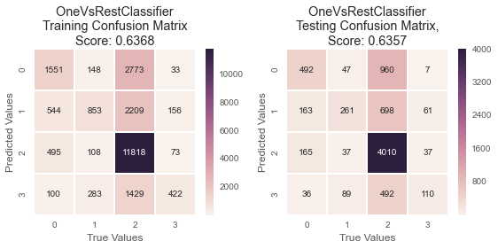

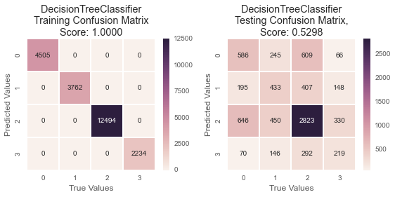

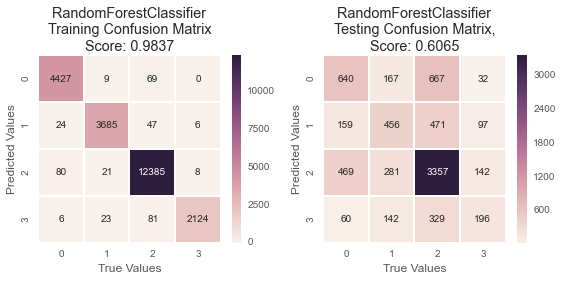

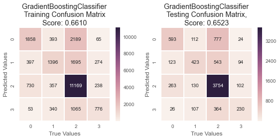

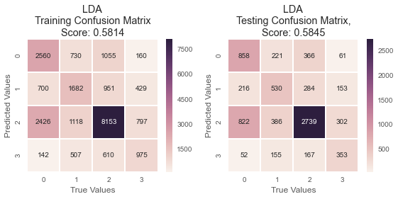

```python
from sklearn.svm import SVC
from sklearn.multiclass import OneVsRestClassifier
from sklearn.naive_bayes import MultinomialNB
from sklearn.tree import DecisionTreeClassifier
from sklearn.ensemble import RandomForestClassifier, GradientBoostingClassifier
from sklearn.lda import LDA

classifiers = [
    OneVsRestClassifier(SVC()),
#     MultinomialNB(class_prior = pitch_percentage),
    DecisionTreeClassifier(),
    RandomForestClassifier(random_state = 100),
    GradientBoostingClassifier(),
    LDA(n_components=len(le.classes_))
]

for model in classifiers:
    clf = model
    clf.fit(X_train, y_train)
    create_confusion_matrix(clf)
```

##### Are there any better metrics you can come up with?

When evaluating a multi class classification problem, it is typically difficult to use many other evaluation metrics as they do not scale well when there are more than two classes present. I would have liked to use an ROC curve to evaluate the predictions, but with a multi-class problem one really can't use this metric. (It is possible but evaluating this metric could possibly be even more confusing). I could decide to use something like a 'Balanced Error Rate' or 'Combined Error Rate' but straight accuracy is still the most suitable in this situation for a multi-class problem.